# 1.Python一切皆对象

## Python一切皆对象

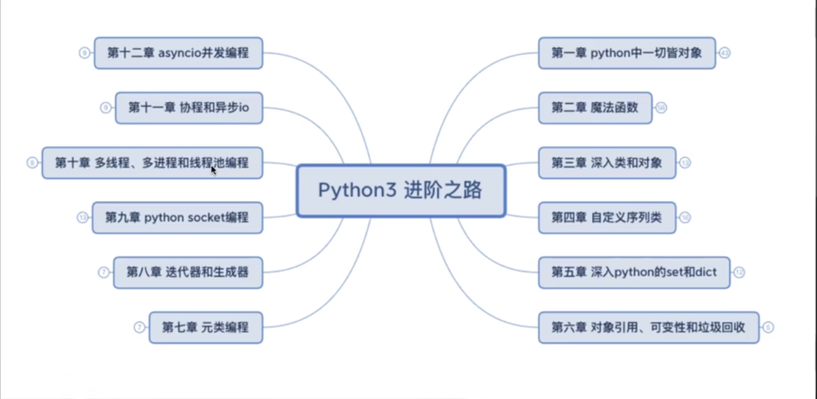

### Python中一切皆对象

#### 对象可以赋值

```python
def print_info():
    print("This is a function")
myprint = print_info
myprint()
```

```
This is a function
```

#### 对象可以添加到集合对象中

```python
object_list = list()
object_list.append(myprint)
for i in object_list:
    print(i)
```

```
<function print_info at 0x1197644a0>
```

#### 可以作为参数传递给函数

> 装饰器是Python中一种强大且灵活的功能，它允许你在不修改原始函数代码的情况下，对函数的行为进行扩展或修改。装饰器本质上是一个函数，它接受一个函数作为参数，并返回一个新的函数。 主要作用包括：

- 代码复用和简化：通过装饰器，可以将一些与函数功能无关的代码抽离出来，提高代码的可读性和可维护性。
- 添加额外功能：装饰器可以在不改变函数结构的情况下，为函数添加额外功能，比如日志记录、性能分析、权限检查等。
- 动态修改函数行为：装饰器可以在运行时动态修改函数的行为，使得函数的功能更加灵活和多样化。
- 包装器：装饰器实际上是一个包装器，它可以在被装饰的函数前后执行代码，实现对函数执行过程的控制。 总之，装饰器为Python提供了一种优雅的方式来修改、扩展或包装函数的功能，使得代码更加模块化、可复用和易于维护。

```python
def my_wrapper(func_obj):
    def wrapper():
        print("这是一个装饰器...")
        func_obj()               # 调用外部函数所接收的函数对象
    return wrapper               # 外部函数返回的是内部函数对象

@my_wrapper
def print_wrapper():
    print("这是一个测试函数...")


# func_obj = my_wrapper(print_wrapper)  #将定义的普通函数传递给my_wrapper
# func_obj()

print_wrapper()
```

```
这是一个装饰器...
这是一个测试函数...
```

### type、object和class的关系

1、Python中所有的类是由类型类创建的 2、Python中的类型都是由Type类创建的

```python
a = 1
b = 'abc'
print(type(a))
print(type(b))
print(type(str))

class Student():
    pass
stu = Student()
print(type(stu))
print(type(Student))
```

```
<class 'int'>
<class 'str'>
<class 'type'>
<class '__main__.Student'>
<class 'type'>
```

3、探究Python中的object type创建了所有的对象，Object也是一个对象

```python
print(int.__bases__)
print(type(object))
print(type.__bases__)
print(object.__bases__)
```

```
(<class 'object'>,)
<class 'type'>
(<class 'object'>,)
()
```

总结： 1、Type创建了所有的对象，也包含类对象(object) 2、Type在创建Object基类同时也继承了object 3、Type是由自创创建的